# Visualising FFTs

Nathaniel Phillips and Hansjörg Neth

2023-06-06

## Visualizing FFTrees

The **FFTrees** package makes it very easy to visualize and evaluate fast-and-frugal trees (FFTs):

- Use the main `FFTrees()` function to create a set of FFTs (e.g., as an R object `x` of type `FFTrees`).
- Visualize a tree in `x` by evaluating `plot(x)`.

The two key arguments for plotting are `what` and `tree`: Whereas the `tree` argument allows selecting between different trees in `x` (using `tree = 1` by default), the `what` argument distinguishes between five main types of plots:

1. `plot(x, what = 'all')` visualizes a tree and corresponding performance statistics. This is also the default when evaluating `plot(x)`.
2. `plot(x, what = 'tree')` visualizes only the tree diagram of the selected tree (without performance statistics).
3. `plot(x, what = 'icontree')` visualizes the tree diagram of the selected tree with icon arrays on exit nodes (with additional options for `show.iconguide` and `n.per.icon`.
4. `plot(x, what = 'cues')` visualizes the current cue accuracies in ROC space (by calling the `showcues()` function).
5. `plot(x, what = 'roc')` visualizes a performance comparison of FFTs and competing algorithms in ROC space.

The other arguments of the `plot.FFTrees()` function allow further customization of the plot (e.g., by defining labels and parameters, or selectively hiding or showing elements).

In the following, we illustrate both ways by creating FFTs based on the `titanic` data (included in the **FFTrees** package).

### The Titanic data

[figure not shown]

The `titanic` dataset contains basic survival statistics of *Titanic* passengers. For each passenger, we know in which class s/he traveled, as well as binary categories specifying age, sex, and survival information. To get a first impression, we inspect a random sample of cases:

```r
set.seed(12)  # reproducible randomness
rcases <- sort(sample(1:nrow(titanic), 10))

# Sample of data:
knitr::kable(titanic[rcases, ], caption = "A sample of 10 observations from the `titanic` data.")
```

A sample of 10 observations from the `titanic` data.

|  | class | age | sex | survived |
| --- | --- | --- | --- | --- |
| 82 | first | adult | male | FALSE |
| 91 | first | adult | male | FALSE |
| 336 | second | adult | male | TRUE |
| 346 | second | adult | male | FALSE |
| 450 | second | adult | male | FALSE |
| 546 | second | adult | female | TRUE |
| 1093 | third | adult | female | TRUE |
| 1160 | third | adult | female | FALSE |
| 1271 | third | child | male | FALSE |
| 1500 | crew | adult | male | TRUE |

Our current goal is to fit FFTs to this dataset. This essentially asks:

- Can we use the information in the cues `class`, `age` and `sex` to decide whether a passenger `survived`?

First, let’s create an `FFTrees` object (called `titanic.fft`) from the `titanic` dataset:

```r
# Create FFTs for the titanic data:
titanic.fft <- FFTrees(formula = survived ~.,
                       data = titanic,
                       main = "Surviving the Titanic",
                       decision.labels = c("Died", "Survived"))
```

Note that we used the entire `titanic` data (i.e., all 2201 cases) to train `titanic.fft`, rather than specifying `train.p` to set aside some proportion of it or specifying a dedicated `data.test` set for predictive purposes. This implies that our present goal is *to fit* FFTs to the historic data, rather than on create and use FFTs *to predict* new cases.

### Visualising cue accuracies

We can visualize individual cue accuracies (specifically their sensitivities and specificities) by including the `what = 'cues'` argument within the `plot()` function. Let’s apply the function to the `titanic.fft` object to see how accurate each of the cues were on their own in predicting survival:

```
#> Plotting cue training statistics:
#> — Cue accuracies ranked by bacc
```

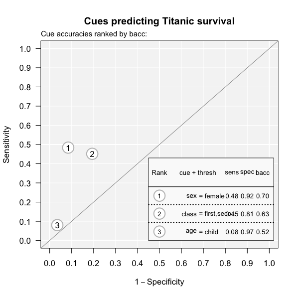

**Figure 1**: Cue accuracies of FFTs predicting survival in the `titanic` dataset.

```r
plot(titanic.fft, what = "cues", main = "Cues predicting Titanic survival")
```

Given the axes of this plot, good performing cues should be near the top left corner of the graph (i.e., exhibit both a low false alarm rate and a high hit rate). For the `titanic` data, this implies that *none* of the cues predicts very well on its own. The best individual cue appears to be `sex` (indicated as 1), followed by `class` (2). By contrast, `age` (3) seems a pretty poor cue for predicting survival on its own (despite its specificity of 97%).

Inspecting cue accuracies can provide valuable information for constructing FFTs. While they provide lower bounds on the performance of trees (as combining cues is only worthwhile when this yields a benefit), even poor individual cues can shine in combination with other predictors.

### Visualizing FFTs and their performance

To visualize the tree from an `FFTrees` object, use `plot()`. Let’s plot one of the trees (Tree #1, i.e., the best one, given our current goal):

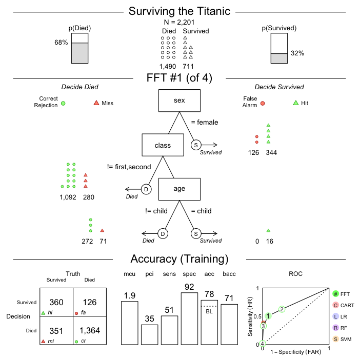

**Figure 2**: Plotting the best FFT of an `FFTrees` object.

```r
plot(titanic.fft, tree = 1)
```

As **Figure 2** contains a lot of information in three distinct panels, let’s briefly consider their contents:

1. *Basic dataset information*: The top row of the plot shows basic information on the current dataset: Its population size (N) and the baseline frequencies of the two categories of the criterion variable.
2. *FFT and classification performance*: The middle row shows the tree (in the center) as well as how many cases (here: persons) were classified at each level in the tree (on either side). For example, the current tree (Tree #1 of 4) can be understood as:
   - If a person is female, decide that they survived.
   - Otherwise, if a person is neither in first nor in second class, decide that they died.
   - Finally, if the person is a child, predict they survived, otherwise decide that they died.
3. *Accuracy and performance information*: The bottom row shows general performance statistics of the FFT:  
   As our models in `titanic.fft` were trained on the entire `titanic` dataset, we fitted FFTs to its 2201 cases, rather than setting aside some data for predictive purposes. The panel label reflects this important distinction:
- If the results of fitting data (i.e., data used to build the tree) are displayed, we’ll see a “Training” label.
- If a testing dataset separate from the one used to build the tree is used, we’ll see a “Prediction” label.

The bottom panel provides performance information and is structured into three subpanels:

1. The classification table (on the left) shows the relationship between the true criterion states (as columns) and predicted decisions (as rows). The abbreviations *hi* (hits) and *cr* (Correct rejections) denote correct decisions; *mi* (misses) and *fa* (false-alarms) denote incorrect decisions.
2. A range of vertical levels (in the middle) show the tree’s cumulative performance in terms of two frugality measures (`mcu` and `pci`) and various accuracy measures (sensitivity, specificity, accuracy, and balanced accuracy (see Accuracy statistics for details).
3. Finally, the plot (on the right) shows an ROC curve comparing the performance of all trees in the `FFTrees` object. Additionally, the performance of logistic regression (blue) and CART (red) are shown. The tree plotted in the middle panel is highlighted in a solid green color (i.e., Figure 2 shows Tree #1).

### Additional arguments

Specifying additional arguments of `plot()` changes what and how various elements are being displayed.

- `what` should be visualized? The `what` argument selects contents to be plotted:
  - When `what = 'all'` (as by default), the plot shows both a tree diagram and a range of corresponding performance statistics. Using one of the other `what` options narrows the range of what is being shown:
  - To only visualize a bare tree diagram (without performance statistics), we specify `what = "tree"` (formerly `stats = FALSE`).
  - To visualize the tree diagram with icon arrays on exit nodes, we specify `what = "icontree"` (with additional options for `show.iconguide` and `n.per.icon`).
  - To visualize the performance comparison (for different FFTs and competing algorithms) in ROC space, we specify `what = "roc"`.

The following examples illustrate the wide range of corresponding plots:

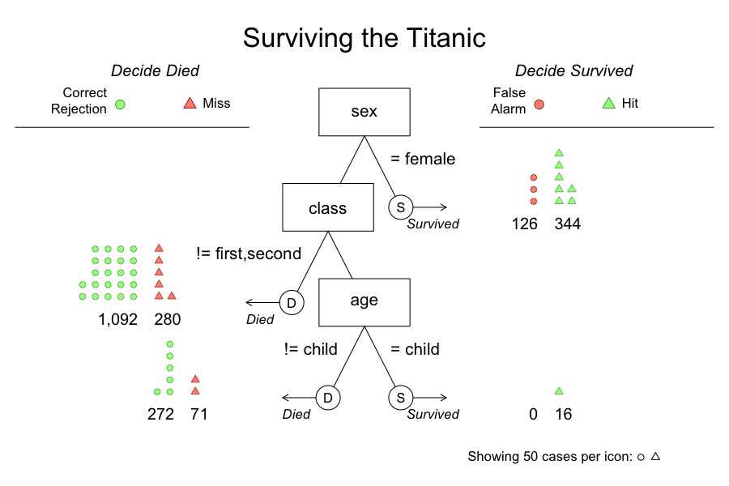

**Figure 3**: An FFT diagram with icon arrays on exit nodes.

```r
# Plot tree diagram with icon arrays:
plot(titanic.fft, what = "icontree",
     n.per.icon = 50, show.iconguide = TRUE)
```

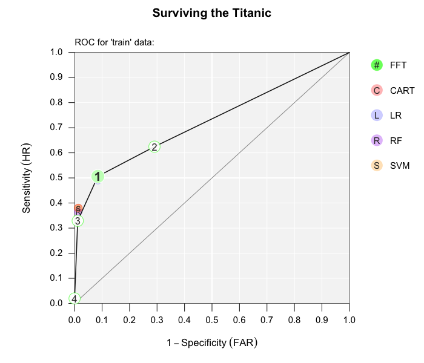

**Figure 4**: Performance comparison of FFTs in ROC space.

```r
# Plot only the performance comparison in ROC space:
plot(titanic.fft, what = "roc")
```

- When the main options for `what` do not suffice, various `show.` arguments (i.e., `show.header`, `show.tree`, `show.confusion`, `show.levels`, `show.roc`, `show.icons`, and `show.iconguide`) allow to selectively turn on or turn off specific elements of the overall plot. For example:

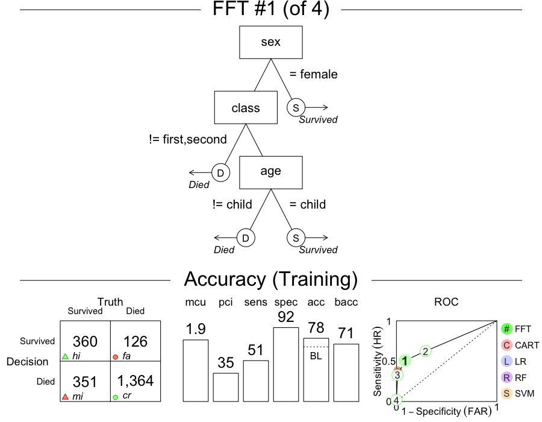

**Figure 5**: Plotting selected elements.

```r
# Hide some elements of the FFT plot:
plot(titanic.fft,
     show.icons = FALSE,     # hide icons
     show.iconguide = FALSE, # hide icon guide
     show.header = FALSE     # hide header
     )
```

- `tree`: Which tree do we want to plot? As `FFTrees` objects typically contain multiple FFTs, we need to indicate which tree we want to visualize. We usually specify the tree to show by an integer value, such as `tree = 2`, which will plot the corresponding tree (i.e., Tree #2) of the `FFTrees` object. Alternatively, we can specify `tree = "best.train"` or `tree = "best.test"` to visualize the best training or prediction tree, respectively. This selects and shows the tree with the highest goal value (e.g., weighted accuracy `wacc`) when fitting or testing data.
- `data`: Which data do we want to apply the tree to? We can specify `data = "train"` or `data = "test"` to distinguish between a training and testing dataset (if available) in the `FFTrees` object. As not all `FFTrees` objects contain test data, `data` is set to `data = "train"` by default.

As the `data` and `tree` arguments can both refer to datasets used for training or fitting (i.e., the “train” or “test” sets), they should be specified consistently. For instance, the following command would visualize the best training tree in `titanic.fft`:

```r
plot(titanic.fft, tree = "best.train")
```

as `data = "train"` by default. However, the following analog expression would fail:

```r
plot(titanic.fft, tree = "best.test")
```

for two distinct reasons:

1. When `data` remains unspecified, its default is `data = "train"`. Thus, asking for `tree = "best.test"` would require switching to `data = "test"`.
2. More crucially, `titanic.fft` was created without any test data. Hence, asking for the best test tree does not make sense — which is why `plot()` will show the best training tree (with a warning).

### Plotting performance for new data

Shifting our emphasis from fitting to prediction, we primarily need to specify some test data that was not used to train the `FFTrees` object. When predicting performance for a new dataset (e.g.; `data = test.data`), the plotting and printing functions will automatically apply an existing `FFTrees` object to the new data and compute corresponding performance statistics (using the `fftrees_apply()` function). However, when applying existing FFTs to new data, the changes to the `FFTrees` object are not stored in the input object, unless the (invisible) output of `plot.FFTrees()` or `print.FFTrees()` is re-assigned to that object. The best way to fit FFTs to training data and evaluate them to test data is to explicitly include both datasets in the original `FFTrees()` command by either using its `data.test` or its `train.p` argument.

For example, we can repeat the previous analysis, but now let’s create separate training and test datasets by including the `train.p = .50` argument. This will split the dataset into a 50% training set, and a distinct 50% testing set. (Alternatively, we could specify a dedicated test data set by using the `data.test` argument.)

```r
set.seed(100)  # for replicability of the training/test split
titanic.pred.fft <- FFTrees(formula = survived ~.,
                            data = titanic,
                            train.p = .50,  # use 50% to train, 50% to test
                            main = "Titanic",
                            decision.labels = c("Died", "Survived")
                            )
```

Here is the best training tree applied to the *training* data:

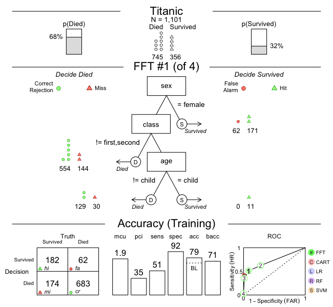

**Figure 6**: Plotting the best FFT on *training* data.

```r
# print(titanic.pred.fft, tree = 1)
plot(titanic.pred.fft, tree = 1)
```

Tree #1 is the best training tree — and could also be visualized by `plot(titanic.pred.fft, tree = "best.train")`. This tree has a high specificity of 92%, but a much lower sensitivity of just 51%. The overall accuracy of the tree’s classifications is at 79%, which exceeds the baseline, but is far from perfect. However, as we can see in the ROC table, a logistic regression (LR) would not perform much better, and CART performed even worse than Tree #1.

Now let’s inspect the performance of the same tree on the *test* data:

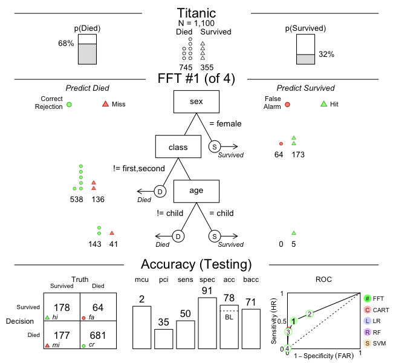

**Figure 7**: Plotting the best FFT on *test* data.

```r
# print(titanic.pred.fft, data = "test", tree = 1)
plot(titanic.pred.fft, data = "test", tree = 1)
```

We could have visualized the same tree by asking for `plot(titanic.pred.fft, data = "test", tree = "best.test")`. Note that the label of the bottom panel has now switched from “Accuracy (Training)” to “Accuracy (Testing)”. Both the sensitivity and specificity values have decreased somewhat, which is typical when using a model (fitted on training data) for predicting new (test) data.

Let’s visualize the prediction performance of Tree #2, the most liberal tree (i.e., with the highest sensitivity):

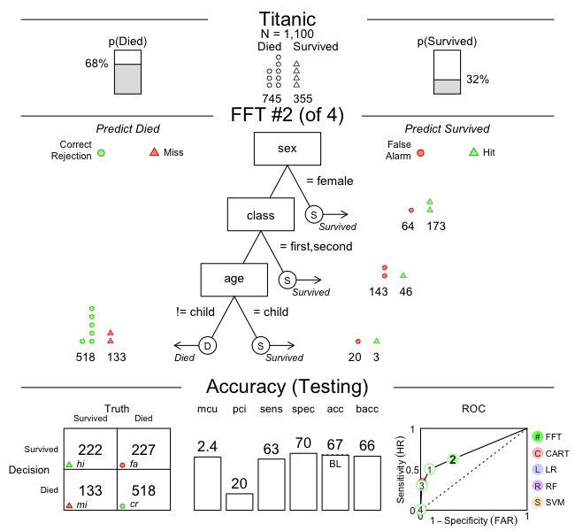

**Figure 8**: Plotting Tree #2.

```r
plot(titanic.pred.fft, data = "test", tree = 2)
```

This alternative tree has a better sensitivity (of 63%), but its overall accuracy decreased to about baseline level (of 67%).

Whereas comparing training with test performance illustrates the trade-offs between mere fitting and genuine predictive modeling, comparing the performance details of various FFTs illustrates the typical trade-offs that any model for solving binary classification problems engages in. Importantly, both types of trade-offs are rendered transparent when using **FFTrees**.

## Vignettes

Here is a complete list of the vignettes available in the **FFTrees** package:

|  | Vignette | Description |
| --- | --- | --- |
|  | Main guide: FFTrees overview | An overview of the **FFTrees** package |
| 1 | Tutorial: FFTs for heart disease | An example of using `FFTrees()` to model heart disease diagnosis |
| 2 | Accuracy statistics | Definitions of accuracy statistics used throughout the package |
| 3 | Creating FFTs with FFTrees() | Details on the main `FFTrees()` function |
| 4 | Manually specifying FFTs | How to directly create FFTs without using the built-in algorithms |
| 5 | Visualizing FFTs | Plotting `FFTrees` objects, from full trees to icon arrays |
| 6 | Examples of FFTs | Examples of FFTs from different datasets contained in the package |